# Introduction to atpolR

The ATPOL grid was created in the late 1960s at the Institute of Botany at Jagiellonian University in Kraków. (Zając 1978a, 1978b) describes the background and methodology. Łukasz Komsta and Marek Verey carried out the extensive mathematical research and GIS implementation (Komsta 2016; Verey 2017). Algorithms provided by Komsta on [OpenATPOL](https://atpol.sourceforge.io/) are basis for implementation in **atpolR** package.

# Basic usage

## Prepare sample data based on published ATPOL data

In our example we’ll use a distribution map of *Erigeron acris* L. subsp. *acris* from (Zając and Zając 2019). The image was scanned at 150 dpi and georeferenced with QGIS.

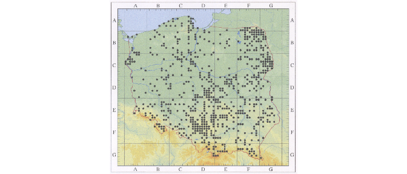

*Erigeron acris* L. subsp. *acris* distribution taken from (Zając and Zając 2019)

```r
par(mar = c(0, 0, 0, 0))
tif <- system.file("extdata/eriacr.tif", package = "atpolR")
r <- terra::rast(tif)
terra::plotRGB(r)
```

There is hundreds of records. To get them all, we will use `check_atpol_square()` function, which takes the POINT coordinates and a raster as arguments and checks if the value of raster cell corresponding to some arbitrary buffer around the POINT equals zero. As the points are drawn in centers of ATPOL 10 km grid, the values of atpol10k() centroids with an buffer with radius of 1200 m will be checked. It may be necessary to adjust a buffer slightly depending of the quality of scan and precision of georeferencing.

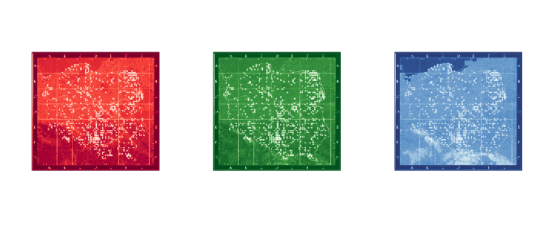

R, G and B layers of a raster

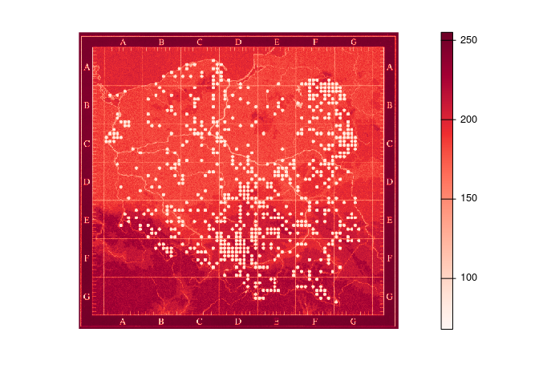

The layer’s values are continuous, ranging from 0 to 255. To simplify and facilitate analysis, we will classify the layer by assigning only two values: 0 and 1. We’ll make a reclassification matrix called `rclmat` and use the `classify()` function form the **terra** package.

```r
m <- c(0,120, 0,
       120,255, 1)
rclmat <- matrix(m, ncol=3, byrow=TRUE)
rc <- terra::classify(r[[1]], rclmat, include.lowest = TRUE)
```

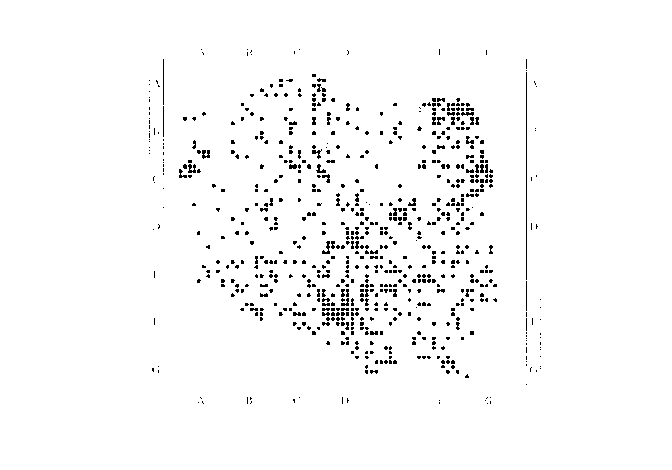

Reclasiffied raster with 0 — as black and 1 — as white

After preparing the raster, we can load the package and run the `check_atpol_square()` function for all 10k grids:

```r
library(atpolR)

eriacr <- atpol10k()|>
  dplyr::mutate(a = mapply(function(x) check_atpol_square(x, rc), centroid)) |>
  dplyr::filter(a == "YES")
```

Let’s display the results:

```r
eriacr
```

```
#> Simple feature collection with 709 features and 2 fields
#> Active geometry column: geometry
#> Geometry type: POLYGON
#> Dimension:     XY
#> Bounding box:  xmin: 170032.6 ymin: 140353.6 xmax: 839912.3 ymax: 778164.1
#> Projected CRS: ETRS89 / Poland CS92
#> First 10 features:
#>    Name                       geometry                  centroid   a
#> 1  AB15 POLYGON ((220203.9 698774.2... POINT (225196.1 693780.2) YES
#> 2  AB21 POLYGON ((180184 688879.5, ... POINT (185177.4 683882.5) YES
#> 3  AB23 POLYGON ((200188.2 688840.5... POINT (205181.3 683844.9) YES
#> 4  AB73 POLYGON ((200121.5 638968.2... POINT (205117.5 633972.6) YES
#> 5  AB83 POLYGON ((200110.3 628991.5...   POINT (205106.9 623996) YES
#> 6  AB94 POLYGON ((210103.7 619001, ... POINT (215100.6 614006.2) YES
#> 7  AB95 POLYGON ((220106.8 618988.3... POINT (225103.5 613994.1) YES
#> 8  AB96 POLYGON ((230109.2 618976, ... POINT (235105.7 613982.3) YES
#> 9  AC05 POLYGON ((220097.7 609011.9... POINT (225094.9 604017.7) YES
#> 10 AC06 POLYGON ((230100.4 609000.3... POINT (235097.4 604006.7) YES
```

There is 709 observations (grids) in data set.

Let’s have a closer look on BE square:

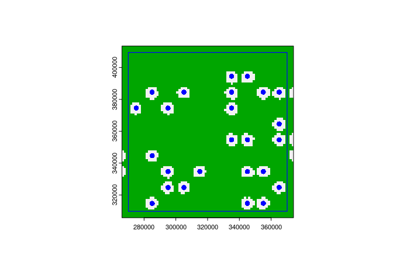

```r
BE <- atpol100k() |>
  subset(Name == "BE") |>
  sf::st_bbox()
par(pty = "s")
plot(NA, type = "n", xlim = c(BE[1], BE[3]), ylim = c(BE[2], BE[4]), axes = FALSE, xlab = "", ylab = "")
terra::plot(rc, legend = FALSE, add = TRUE)

atpol100k() |>
  subset(Name == "BE") |>
  sf::st_cast("LINESTRING") |>
  terra::plot(add = TRUE, col = "blue", lwd = 1.2)

eriacr |>
  subset(substr(Name, 1, 2) == "BE") |>
  sf::st_set_geometry("centroid") |>
  terra::plot(pch = 16, cex = 1.2, col = "blue", add = TRUE)
```

Thus far, so god. Our data set corresponds to published data. In the next step we will add our own observations.

Please keep in mind that `check_atpol_square()` function can produce false positive results in the case of noisy scans. it also does not recognize the various shapes used in original publications for various sites.

## Extend the data

Assume we want to add our own observations the data set. If we already know the grid name, we can simply use the Name to filter out the grid created by the `atpol10k()` function. We can use `latlon_to_grid()` function if we don’t have the grid but have coordinates. In the following example, we are using both methods:

```r
myData <- atpol10k() |>
  dplyr::filter(Name %in% c("BE68",
                            latlon_to_grid(51.13619, 16.95069, 4))) |>
  dplyr::mutate(a = "myData")
```

And let’s add them to above BE square plot:

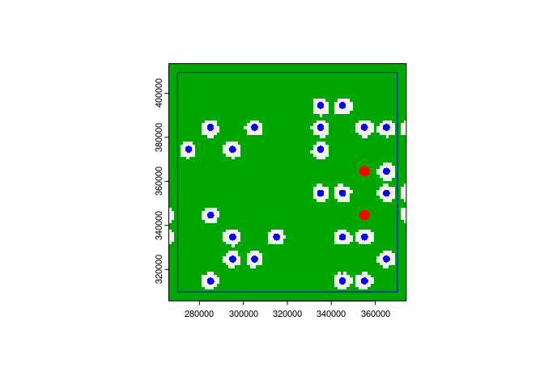

Data set extended with our observations in grids BE48 and BE68

```r
myData |>
  sf::st_set_geometry("centroid") |>
  terra::plot(pch = 16, cex = 1.8, col = "red", add = TRUE)
```

## Plot it

```r
eriacr <- eriacr |>
  rbind(myData) |>
  unique.data.frame()
```

And final plot.

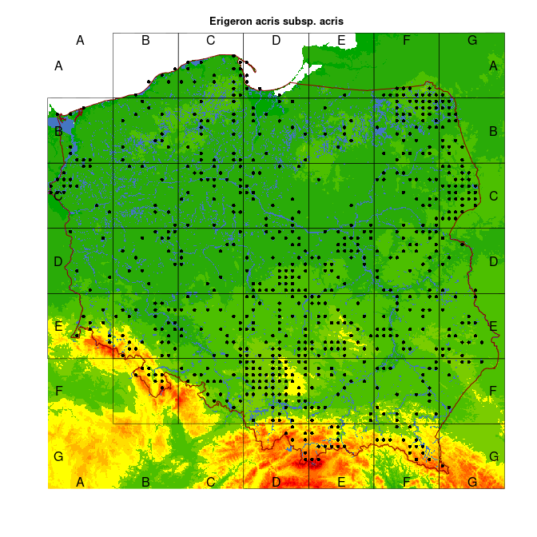

Combined dataset drawn on ATPOL grid

```r
plotPoitsOnAtpol(eriacr$centroid, main = "Erigeron acris subsp. acris", cex = 0.6)
```

# Functions description

Two basic functions `latlon_to_grid()` and `grid_to_latlon()` allows to quickly convert geographical coordinates (given in WGS 84 latitude and longitude degrees) to ATPOL grid and from grid to coordinates respectively.

```r
latlon_to_grid(51.01234, 17.23456, 4)
```

```
#> [1] "CE50"
```

```r
latlon_to_grid(51.01234, 17.23456, 6)
```

```
#> [1] "CE5086"
```

The firs two arguments `latlon_to_grid()` function are latitude and longitude respectively. The third argument is the length of returned grid; it might be even number between 2 and 12.

```r
grid_to_latlon("CE50")
```

```
#> [1] 51.04487 17.21736
```

By default `grid_to_latlon()` returns the center of grid square. If you wish to get it’s corners, you can pass another 2 arguments to the function, which are X and Y offsets, like:

```r
grid_to_latlon("CE50", xoffset = 1, yoffset = 1)
```

```
#> [1] 51.00114 17.29032
```

for bottom right corner.

ATPOL 10km x 10km and 100km x 100k grids are generated by `atpol10k()` and `atpol100k()` functions respectively. It returns set of simple features geometries with grids as polygons:

```r
atpol100k()
```

```
#> Simple feature collection with 44 features and 1 field
#> Geometry type: POLYGON
#> Dimension:     XY
#> Bounding box:  xmin: 170009.4 ymin: 110297.1 xmax: 870031.4 ymax: 808651.9
#> Projected CRS: ETRS89 / Poland CS92
#> First 10 features:
#>    Name                       geometry
#> 1    AB POLYGON ((170084 619056.2, ...
#> 2    AC POLYGON ((170014.5 519234.8...
#> 3    AD POLYGON ((170011.8 459334.6...
#> 4    AE POLYGON ((170072 359522.7, ...
#> 5    BA POLYGON ((270217.8 718621.1...
#> 6    BB POLYGON ((270112.1 618931.2...
#> 7    BC POLYGON ((270062.8 519180.9...
#> 8    BD POLYGON ((270060.2 459322.1...
#> 9    BE POLYGON ((270101.2 359577, ...
#> 10   BF POLYGON ((270198.4 259898.5...
```

For 10k grid it returns a centroids as well:

```r
atpol10k()
```

```
#> Simple feature collection with 4400 features and 1 field
#> Active geometry column: geometry
#> Geometry type: POLYGON
#> Dimension:     XY
#> Bounding box:  xmin: 170009.4 ymin: 110297.1 xmax: 870031.4 ymax: 808651.9
#> Projected CRS: ETRS89 / Poland CS92
#> First 10 features:
#>     Name                       geometry                  centroid
#> 101 AB00 POLYGON ((170215.7 708847.7... POINT (175207.9 703850.1)
#> 102 AB01 POLYGON ((180217.9 708825.6...   POINT (185210 703828.7)
#> 103 AB02 POLYGON ((190219.4 708804.1...   POINT (195211.3 703808)
#> 104 AB03 POLYGON ((200220 708783.2, ... POINT (205211.9 703787.9)
#> 105 AB04 POLYGON ((210219.9 708763.1... POINT (215211.7 703768.4)
#> 106 AB05 POLYGON ((220219.1 708743.6... POINT (225210.8 703749.6)
#> 107 AB06 POLYGON ((230217.5 708724.8... POINT (235209.1 703731.5)
#> 108 AB07 POLYGON ((240215.3 708706.6...   POINT (245206.8 703714)
#> 109 AB08 POLYGON ((250212.4 708689.1... POINT (255203.9 703697.2)
#> 110 AB09 POLYGON ((260208.9 708672.3... POINT (265200.3 703681.1)
```

Please note, that ATPOL grids are projected in EPSG:2180 coordinate reference system, commonly used in Poland.

Function `atpol_div(grid, divider)` divides any given `grid` to smaller grids by 2, 4 or 5 as proposed in (Verey and Komsta 2018).

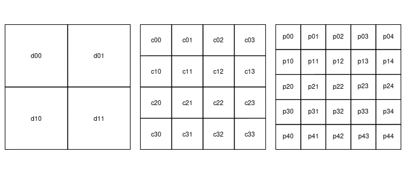

Division by 2, 4 and 5 with adopted naming convection d, c, p

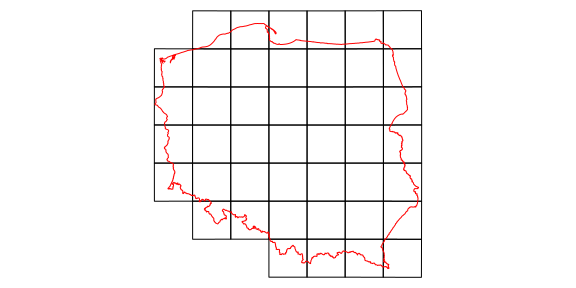

Boundary of Poland on ATPOL grid.

```r
par(mar = c(0, 0, 0, 0))
b <- boundaryPL()
plot(atpol100k()$geometry)
plot(b, col = "red", add = TRUE)
```

# Bibliography

Komsta, Łukasz. 2016. “Rewizja Matematyczna Siatki Geobotanicznej ATPOL – Propozycja Algorytmów Konwersji Współrzędnych.” *Annales UMCS, Sectio E, Agricultura* LXXI (1): 31–37. https://czasopisma.up.lublin.pl/index.php/as/article/view/554.

Verey, Marek. 2017. “Teoretyczna Analiza i Praktyczne Konsekwencje Przyjęcia Modelowej Siatki ATPOL Jako Odwzorowania Stożkowego Definiującego Konwersję Współrzędnych Płaskich Na Elipsoidę WGS 84.” *Fragmenta Floristica Et Geobotanica Polonica* 24 (2): 469–88. http://bomax.botany.pl/pubs-new/#article-4279.

Verey, Marek, and Łukasz Komsta. 2018. “Standaryzacja Zapisu Podziałów Siatki ATPOL.” *Fragmenta Floristica Et Geobotanica Polonica* 25 (1): 107–11. http://bomax.botany.pl/pubs-new/#article-4302.

Zając, Adam. 1978a. “Założenia Metodyczne "Atlasu Rozmieszczenia Roślin Naczyniowych w Polsce".” *Wiadomości Botaniczne* XXII (3): 145–55.

———. 1978b. “Atlas of Distribution of Vascular Plants in Poland (ATPOL).” *TAXON* 27 (5-6): 481–84.

Zając, Adam, and Maria Zając, eds. 2019. *Atlas Rozmieszczenia Roślin Naczyniowych w Polsce: Dodatek. Distribution Atlas of Vascular Plants in Poland: Appendix*. Kraków: Instytut Botaniki Uniwersytetu Jagiellońskiego.